# Dyskretyzacja i redukcja wymiaru na podstawie danych iris, City Quality of Life Dataset, titanic_train

## Porównanie nienadzorowanych metod dyskretyzacji

```r
library(arules)
library(cluster)
library(dplyr)
b <- iris[,"Petal.Length"]
w <- iris[,"Sepal.Width"]
n <- length(b)
y = runif(n)
b.disc.equal.freq <- discretize(b, breaks = 3)
t1 <-table(b.disc.equal.freq, iris$Species)
t1
```

```
##
## b.disc.equal.freq setosa versicolor virginica
##        [1,2.63)       50          0         0
##        [2.63,4.9)      0         46         3
##        [4.9,6.9]       0          4        47
```

```r
w.disc.equal.freq <- discretize(w, breaks = 3)
t2 <- table(w.disc.equal.freq, iris$Species)
```

Powyższa tabela przedstawia nam wyniki dysktretyzacji opartej na równych częstościach

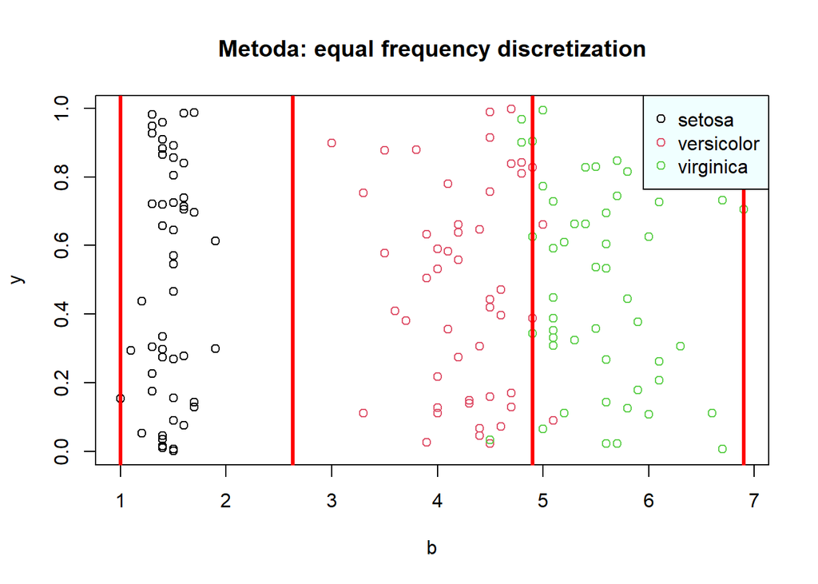

```r
breaks.equal.frequency <- attributes(b.disc.equal.freq)$"discretized:breaks"
plot(b, y, col=iris$Species, main = "Metoda: equal frequency discretization")
abline(v = breaks.equal.frequency, col = "red", lwd=3)
legend(x = "topright", legend=levels(iris$Species), col=1:3, pch=21, bg = "azure")
```

```r
library(e1071)
matchClasses(t1)
```

```
## Cases in matched pairs: 95.33 %
```

```
##     [1,2.63)   [2.63,4.9)    [4.9,6.9]
##     "setosa" "versicolor"  "virginica"
```

Widzimy że metoda equal frequency discretization poradziła sobie dostyć dobrze, ze zgodnością ok. 95,3% dla zmiennej `Petal.Length`. Zobaczmy teraz jak to wygląda dla zmiennej `Sepal.Width`

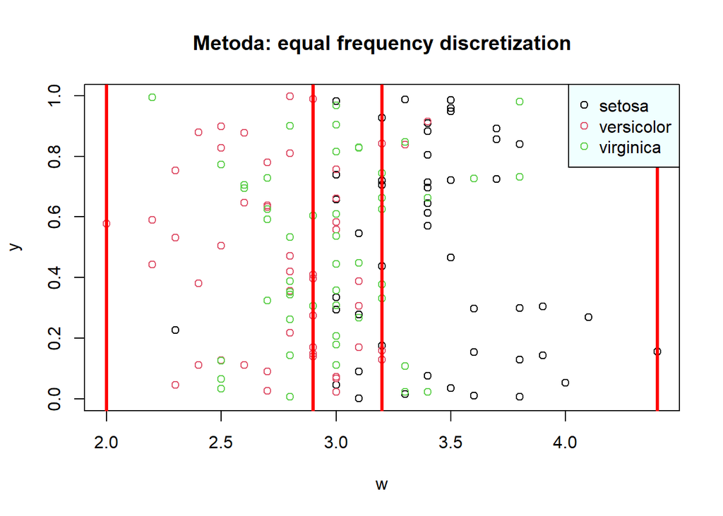

```r
breaks.equal.frequency <- attributes(w.disc.equal.freq)$"discretized:breaks"
plot(w, y, col=iris$Species, main = "Metoda: equal frequency discretization")
abline(v = breaks.equal.frequency, col = "red", lwd=3)
legend(x = "topright", legend=levels(iris$Species), col=1:3, pch=21, bg = "azure")
```

```r
library(e1071)
matchClasses(t2)
```

```
## Cases in matched pairs: 55.33 %
```

```
##      [2,2.9)    [2.9,3.2)    [3.2,4.4]
## "versicolor" "versicolor"     "setosa"
```

Widzimy, że dla tej zmiennej kompletnie zawodzi dyskretyzacja. Dopasowanie jest na poziomie ok. 55,3%.

Przeprowadźmy teraz analize dla dyskretyzacji opartej na przedziałach o jednakowej szerokości (ang. equal interval width)

```r
b.disc.equal.width <- discretize(b, method = "interval", breaks = 3)
t1 <-table(b.disc.equal.width, iris$Species)
t1
```

```
##
## b.disc.equal.width setosa versicolor virginica
##        [1,2.97)        50          0         0
##        [2.97,4.93)      0         48         6
##        [4.93,6.9]       0          2        44
```

```r
w.disc.equal.width <- discretize(w, method = "interval", breaks = 3)
t2 <- table(w.disc.equal.width, iris$Species)
```

Powyższa tabela przedstawia nam wyniki dysktretyzacji opartej na przedziałach o jednakowej szerokości

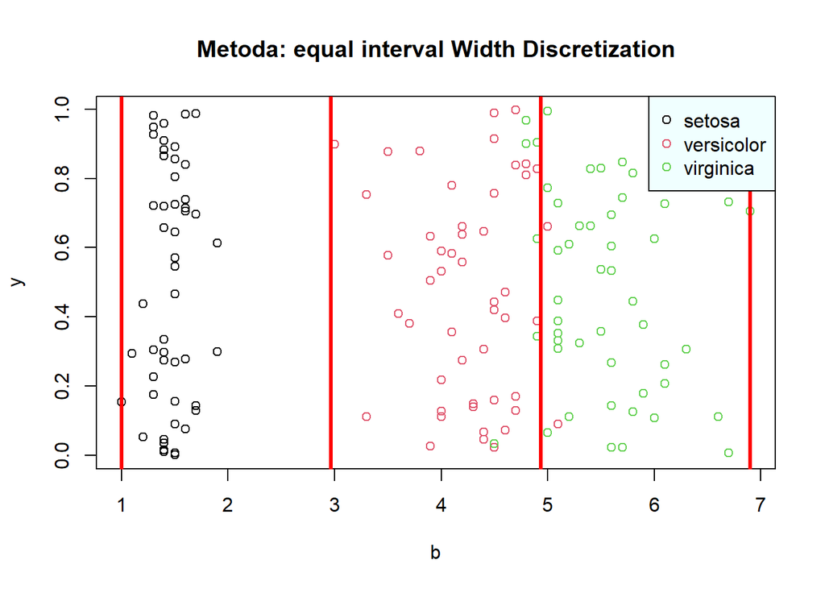

```r
breaks.equal.width <- attributes(b.disc.equal.width)$"discretized:breaks"
plot(b, y, col=iris$Species, main = "Metoda: equal interval Width Discretization")
abline(v = breaks.equal.width, col = "red", lwd=3)
legend(x = "topright", legend=levels(iris$Species), col=1:3, pch=21, bg = "azure")
```

```r
matchClasses(t1)
```

```
## Cases in matched pairs: 94.67 %
```

```
##     [1,2.97)  [2.97,4.93)   [4.93,6.9]
##     "setosa" "versicolor"  "virginica"
```

Widzimy, że ta metoda jest również bardzo dobra, ma zgodność na poziomie ok. 94,7%.